# hw6.Rmd.Rmd

Juan Simons, Github: Giltbuckle 3

4/21/2020

## Top dogs

In this homework, you will try to reproduce the fantastic infographic for [top dogs](https://informationisbeautiful.net/visualizations/best-in-show-whats-the-top-data-dog/), originally produced by David McCandless. The raw data can be found [here](https://docs.google.com/spreadsheets/d/1l_HfF5EaN-QgnLc2UYdCc7L2CVrk0p3VdGB1godOyhk/edit#gid=10). You can download this file by File – Download As – Microsoft Excel (.xlsx).

**Submission instructions**: Create a folder named `ds202_hw6`, and name the RMarkDown file including your solutions `hw6.Rmd` under this folder. For the submission, create a GitHub repository named `ds202_hw6` under your GitHub account, and push both `hw6.Rmd` and the knitted `hw6.html` before the deadline. I will assume you use the same GitHub username as for your HW5 submission. The latest version of your homework appearing on GitHub before the deadline is graded. *It is crucial to follow the exact folder structure and file names*, so that your homework can be reproduced and graded by an automated script. This homework is **due on April 22** before class.

1. Import the data and clean appropriately. To read in the data, you can use `readxl::read_xlsx('fileNameHere', sheet='sheetNameHere')`. Required data are in the sheets `Best in show` and `Best in show full sheet`. Take extra care on the column names and the first few rows of the data frame after read in.

```r
best=readxl::read_xlsx('KIB - Best in Show (public).xlsx', sheet='Best in show')
```

```
## * `` -> ...2
## * `` -> ...3
## * `` -> ...4
## * `` -> ...5
## * `` -> ...6
## * ... and 49 more problems
```

```r
bestf=readxl::read_xlsx('KIB - Best in Show (public).xlsx', sheet='Best in show full sheet')
```

```
## * `` -> ...2
## * `` -> ...4
## * `` -> ...5
## * `` -> ...9
## * `` -> ...10
## * ... and 59 more problems
```

```r
#Lets start by extracting the data we need for the plot.
bestf <- bestf%>% select(1,3,5,6,11,32)
bestf <- bestf[-(1:3),]

#lets get rid of those pesky NA values and rename our columns
bestf<- na.omit(bestf)
names(bestf)<- c("breed","category","score","popularity","intelligence","size")

#Now to convert some of the column types.
bestf$size <- as.factor(bestf$size)

bestf$intelligence <- as.numeric(bestf$intelligence)
bestf$score <- as.numeric(bestf$score)
bestf$popularity <- as.numeric(bestf$popularity)

#This will determine wether a dog is intelligent based off their score in the inteligence column. True for intelligent, false for dumb
bestf <- bestf %>% mutate(intelligence = (intelligence<45))
```

2. Create a graphics similar to the [top dogs](https://informationisbeautiful.net/visualizations/best-in-show-whats-the-top-data-dog/) figure. Your figure needs to display the following information with appropriate plotting elements:
- breed of dog
- type of dog (work, toy, etc.)
- size of dog
- data score
- popularity
- intelligence of the dog
- appropriate legends & explanation

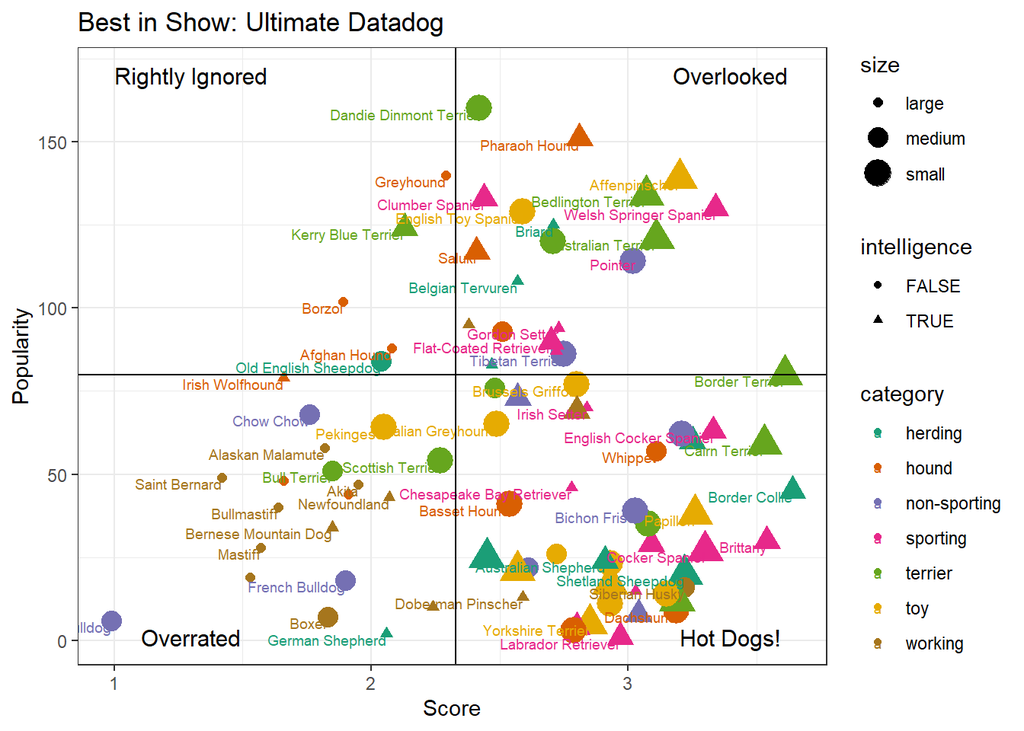

```r
bestf%>% ggplot(aes(x = score, y = popularity, color = category, label = breed, shape = intelligence, size = size)) + geom_point()+ geom_text(check_overlap = TRUE, size = 2.5, hjust = 1, vjust = 1) + theme_bw() + labs(title = "Best in Show: Ultimate Datadog", x = "Score", y ="Popularity")+ geom_hline(yintercept=80) + geom_vline(xintercept=2.33)+ annotate(geom='text', x=1.3, y=1, label='Overrated', size=4) +
  annotate(geom='text', x=3.4, y=1, label='Hot Dogs!', size=4) +
  annotate(geom='text', x=1.3, y=170, label='Rightly Ignored', size=4) +
  annotate(geom='text', x=3.4, y=170, label='Overlooked', size=4)+scale_color_brewer(palette="Dark2")
```

The graph above reprents where each dog landed in the ratings. There are 4 general categories based off of each sector of the graph and they are: Rightly ignored, Overrated, Hot Dogs and Overlooked.

Hints and Notes:

- The breed of dog can be displayed without the silhouttes (text only is fine)
- Avoid (too much) overlaps!
- Choose a good color scheme.
- Your submission is supposed to be fully reproducible, i.e. the TA and I will ‘knit’ your submission in RStudio.